# cytoJointR against COMPASS and polyICSFlow on public TB ICS data

Purpose: show the TB real-data benchmark (`scripts/22`, `23`, `31`): TB-status AUC, rank agreement, antigen sanity check, model criticism of m1dm and runtimes. Run: `quarto render notebooks/realdata_tb.qmd` from the repo root with `R_LIBS=renv/lib` and the R4_51 `PATH`. Inputs: `data/processed/<dataset>/` and `RUN_DIR/<dataset>/`. Outputs: this page. CCS is experimental and no statement below rests on it.

```r
# Parameters -------------------------------------------------------------------
RUN_DIR <- Sys.getenv("TB_RUN_DIR", "runs/2026-11-03_realdata/tb") # run dir of 31_analyse-tb.R, relative to the repo root
DATASETS <- c(tb_s = "TB_s (MTB-specific)", tb_u = "TB_u (non-specific)", tb_simplecompass = "SimpleCOMPASS (EPTB vs IGRA+)") # data set label
HEADLINE <- c( # method score pairs drawn in ROC and agreement plots; the first is the reference
  "m1dm P_RMS_gt_eps", "m1dm RMS_mean", "m1dm CPS_mean", "m1 P_RMS_gt_eps", "C0 P_RMS_gt_eps",
  "COMPASS FS", "COMPASS PFS", "COMPASS Response",
  "polyICSFlow_clipped net_sum", "polyICSFlow_unclipped net_sum"
)
PPC_LEVEL <- 0.9 # nominal level of the replicate intervals in 31_analyse-tb.R
```

```r
suppressPackageStartupMessages({
  library(dplyr)
  library(forcats)
  library(ggplot2)
  library(purrr)
  library(readr)
  library(stringr)
  library(tidyr)
})
theme_set(theme_bw(base_size = 9))
rd <- \(ds, f, ...) read_tsv(file.path(here::here(RUN_DIR), ds, f), show_col_types = FALSE, col_types = cols(donor_id = "c", pattern_key = "c", ...))
by_ds <- \(f, ...) names(DATASETS) |> set_names() |> map(\(ds) rd(ds, f, ...)) |> list_rbind(names_to = "dataset") |> mutate(dataset = fct(dataset, levels = names(DATASETS)))
method_pal <- c(
  "m1dm" = "#1b6ca8", "m1" = "#6aa9d8", "C0" = "#8c8c8c", "COMPASS" = "#d95f02",
  "polyICSFlow_clipped" = "#1b9e77", "polyICSFlow_unclipped" = "#7fc97f"
)
col_of <- \(method) {
  stopifnot("unknown method" = all(method %in% names(method_pal)))
  method_pal[method]
}
```

## Data checks

COMPASS pre-filtered the TB_s and TB_u tables and folded removed patterns into the all-negative count, so the positive counts are lower bounds; the SimpleCOMPASS table is a complete 256-pattern partition.

```r
prep <- names(DATASETS) |>
  set_names() |>
  map(\(ds) read_tsv(file.path(here::here("data/processed"), ds, "prep_log.tsv"), show_col_types = FALSE) |> mutate(across(everything(), as.character))) |>
  list_rbind(names_to = "dataset") |>
  pivot_longer(-dataset, names_to = "check", values_to = "value") |>
  pivot_wider(names_from = dataset, values_from = value)
knitr::kable(prep)
```

| check | tb_s | tb_u | tb_simplecompass |
| --- | --- | --- | --- |
| stim_cells_min_max | 9091-87567 | 7622-100626 | NA |
| n_case | 22 | 22 | 11 |
| n_noncase | 18 | 18 | 10 |
| patterns_only_dropped_markers_positive | 2 | 2 | NA |
| cells_moved_to_allneg_stim | 4122 | 6335 | 151290 |
| cells_moved_to_allneg_ctrl | 3335 | 3335 | 88182 |
| control_N_equals_other_dataset | TRUE | TRUE | NA |
| markers_native | IFNg,IL2,CD154,IL22,IL4,IL17a,TNFa | IFNg,IL2,CD154,IL22,IL4,IL17a,TNFa | IFNg,IL2,IL10,IL17A,IL17F,IL22,MIP1b,TNF |
| markers_kept | IFNg,IL2,TNFa,CD154,IL17a | IFNg,IL2,TNFa,CD154,IL17a | IFNg,IL2,TNF,IL17A,IL22 |
| markers_dropped | IL22,IL4 | IL22,IL4 | IL10,IL17F,MIP1b |
| patterns_native_kept_by_compass | 22 | 19 | 256 |
| patterns_native_possible | 128 | 128 | 256 |
| patterns_reduced_possible | 32 | 32 | 32 |
| patterns_reduced_nonzero | 16 | 13 | 32 |
| n_donors | 40 | 40 | 21 |
| patterns_complete_partition | NA | NA | TRUE |
| csv_samples | NA | NA | 42 |
| csv_control_spellings | NA | NA | UnStimulated / Unstimulated |
| donors_with_other_than_one_stim_and_one_control | NA | NA | 0 |

## TB-status AUC

AUC is the probability that a random case outscores a random non-case; intervals are percentile bootstraps over donors within group (2000 resamples), so with 21 to 40 donors they are wide.

```r
auc <- by_ds("auc.tsv") |>
  mutate(label = paste(method, score))
auc |>
  filter(!str_detect(score, "CCS")) |>
  mutate(across(c(auc, lower, upper), \(v) round(v, 2)), AUC = sprintf("%.2f [%.2f, %.2f]", auc, lower, upper)) |>
  select(dataset, method, score, AUC, n_case, n_noncase) |>
  knitr::kable()
```

| dataset | method | score | AUC | n_case | n_noncase |
| --- | --- | --- | --- | --- | --- |
| tb_s | m1dm | P_RMS_gt_eps | 0.76 [0.59, 0.90] | 22 | 18 |
| tb_s | m1dm | RMS_mean | 0.70 [0.53, 0.86] | 22 | 18 |
| tb_s | m1dm | CPS_mean | 0.84 [0.70, 0.95] | 22 | 18 |
| tb_s | m1dm | P_RMS_gt_1e-05 | 0.76 [0.59, 0.90] | 22 | 18 |
| tb_s | m1dm | P_RMS_gt_0.001 | 0.66 [0.48, 0.81] | 22 | 18 |
| tb_s | m1dm | P_RMS_gt_0.01 | 0.50 [0.50, 0.50] | 22 | 18 |
| tb_s | m1 | P_RMS_gt_eps | 0.88 [0.74, 0.97] | 22 | 18 |
| tb_s | m1 | RMS_mean | 0.86 [0.73, 0.96] | 22 | 18 |
| tb_s | m1 | CPS_mean | 0.81 [0.67, 0.92] | 22 | 18 |
| tb_s | m1 | P_RMS_gt_1e-05 | 0.88 [0.75, 0.97] | 22 | 18 |
| tb_s | m1 | P_RMS_gt_0.001 | 0.86 [0.72, 0.95] | 22 | 18 |
| tb_s | m1 | P_RMS_gt_0.01 | 0.52 [0.50, 0.57] | 22 | 18 |
| tb_s | C0 | P_RMS_gt_eps | 0.73 [0.56, 0.88] | 22 | 18 |
| tb_s | C0 | RMS_mean | 0.68 [0.51, 0.85] | 22 | 18 |
| tb_s | C0 | CPS_mean | 0.83 [0.68, 0.94] | 22 | 18 |
| tb_s | C0 | P_RMS_gt_1e-05 | 0.75 [0.58, 0.90] | 22 | 18 |
| tb_s | C0 | P_RMS_gt_0.001 | 0.66 [0.49, 0.82] | 22 | 18 |
| tb_s | C0 | P_RMS_gt_0.01 | 0.50 [0.50, 0.50] | 22 | 18 |
| tb_s | COMPASS | FS | 0.99 [0.95, 1.00] | 22 | 18 |
| tb_s | COMPASS | PFS | 0.95 [0.88, 1.00] | 22 | 18 |
| tb_s | COMPASS | Response | 0.99 [0.95, 1.00] | 22 | 18 |
| tb_s | polyICSFlow_clipped | net_sum | 0.72 [0.56, 0.86] | 22 | 18 |
| tb_s | polyICSFlow_unclipped | net_sum | 0.69 [0.52, 0.84] | 22 | 18 |
| tb_u | m1dm | P_RMS_gt_eps | 0.65 [0.47, 0.82] | 22 | 18 |
| tb_u | m1dm | RMS_mean | 0.60 [0.42, 0.78] | 22 | 18 |
| tb_u | m1dm | CPS_mean | 0.72 [0.54, 0.88] | 22 | 18 |
| tb_u | m1dm | P_RMS_gt_1e-05 | 0.66 [0.48, 0.83] | 22 | 18 |
| tb_u | m1dm | P_RMS_gt_0.001 | 0.56 [0.38, 0.74] | 22 | 18 |
| tb_u | m1dm | P_RMS_gt_0.01 | 0.50 [0.50, 0.50] | 22 | 18 |
| tb_u | m1 | P_RMS_gt_eps | 0.76 [0.59, 0.90] | 22 | 18 |
| tb_u | m1 | RMS_mean | 0.77 [0.60, 0.92] | 22 | 18 |
| tb_u | m1 | CPS_mean | 0.69 [0.51, 0.85] | 22 | 18 |
| tb_u | m1 | P_RMS_gt_1e-05 | 0.70 [0.53, 0.86] | 22 | 18 |
| tb_u | m1 | P_RMS_gt_0.001 | 0.66 [0.48, 0.82] | 22 | 18 |
| tb_u | m1 | P_RMS_gt_0.01 | 0.50 [0.50, 0.50] | 22 | 18 |
| tb_u | C0 | P_RMS_gt_eps | 0.64 [0.45, 0.81] | 22 | 18 |
| tb_u | C0 | RMS_mean | 0.59 [0.40, 0.78] | 22 | 18 |
| tb_u | C0 | CPS_mean | 0.65 [0.46, 0.83] | 22 | 18 |
| tb_u | C0 | P_RMS_gt_1e-05 | 0.64 [0.46, 0.82] | 22 | 18 |
| tb_u | C0 | P_RMS_gt_0.001 | 0.54 [0.36, 0.72] | 22 | 18 |
| tb_u | C0 | P_RMS_gt_0.01 | 0.50 [0.50, 0.50] | 22 | 18 |
| tb_u | COMPASS | FS | 0.86 [0.73, 0.96] | 22 | 18 |
| tb_u | COMPASS | PFS | 0.86 [0.73, 0.96] | 22 | 18 |
| tb_u | COMPASS | Response | 0.86 [0.73, 0.96] | 22 | 18 |
| tb_u | polyICSFlow_clipped | net_sum | 0.63 [0.46, 0.80] | 22 | 18 |
| tb_u | polyICSFlow_unclipped | net_sum | 0.58 [0.41, 0.76] | 22 | 18 |
| tb_simplecompass | m1dm | P_RMS_gt_eps | 0.55 [0.50, 0.65] | 11 | 10 |
| tb_simplecompass | m1dm | RMS_mean | 0.85 [0.63, 1.00] | 11 | 10 |
| tb_simplecompass | m1dm | CPS_mean | 0.37 [0.13, 0.64] | 11 | 10 |
| tb_simplecompass | m1dm | P_RMS_gt_1e-05 | 0.55 [0.50, 0.65] | 11 | 10 |
| tb_simplecompass | m1dm | P_RMS_gt_0.001 | 0.55 [0.50, 0.65] | 11 | 10 |
| tb_simplecompass | m1dm | P_RMS_gt_0.01 | 0.70 [0.55, 0.85] | 11 | 10 |
| tb_simplecompass | m1 | P_RMS_gt_eps | 0.55 [0.50, 0.65] | 11 | 10 |
| tb_simplecompass | m1 | RMS_mean | 0.80 [0.57, 0.97] | 11 | 10 |
| tb_simplecompass | m1 | CPS_mean | 0.85 [0.65, 1.00] | 11 | 10 |
| tb_simplecompass | m1 | P_RMS_gt_1e-05 | 0.55 [0.50, 0.65] | 11 | 10 |
| tb_simplecompass | m1 | P_RMS_gt_0.001 | 0.55 [0.50, 0.65] | 11 | 10 |
| tb_simplecompass | m1 | P_RMS_gt_0.01 | 0.70 [0.55, 0.85] | 11 | 10 |
| tb_simplecompass | C0 | P_RMS_gt_eps | 0.55 [0.50, 0.65] | 11 | 10 |
| tb_simplecompass | C0 | RMS_mean | 0.85 [0.63, 1.00] | 11 | 10 |
| tb_simplecompass | C0 | CPS_mean | 0.37 [0.13, 0.64] | 11 | 10 |
| tb_simplecompass | C0 | P_RMS_gt_1e-05 | 0.55 [0.50, 0.65] | 11 | 10 |
| tb_simplecompass | C0 | P_RMS_gt_0.001 | 0.55 [0.50, 0.65] | 11 | 10 |
| tb_simplecompass | C0 | P_RMS_gt_0.01 | 0.70 [0.55, 0.85] | 11 | 10 |
| tb_simplecompass | COMPASS | FS | 0.67 [0.42, 0.90] | 11 | 10 |
| tb_simplecompass | COMPASS | PFS | 0.56 [0.30, 0.81] | 11 | 10 |
| tb_simplecompass | COMPASS | Response | 0.67 [0.42, 0.90] | 11 | 10 |
| tb_simplecompass | polyICSFlow_clipped | net_sum | 0.87 [0.66, 1.00] | 11 | 10 |
| tb_simplecompass | polyICSFlow_unclipped | net_sum | 0.85 [0.63, 1.00] | 11 | 10 |

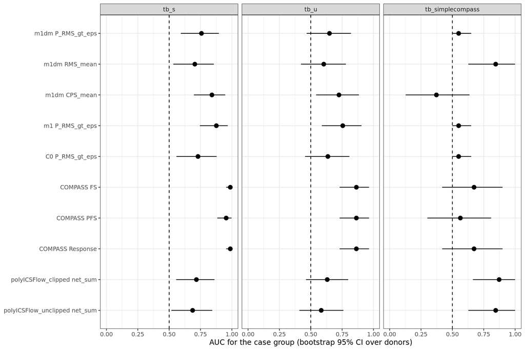

```r
auc_plot <- auc |>
  filter(label %in% HEADLINE) |>
  mutate(label = fct_rev(fct(label, levels = HEADLINE)))
ggplot(auc_plot, aes(auc, label)) +
  geom_vline(xintercept = 0.5, linetype = 2) +
  geom_pointrange(aes(xmin = lower, xmax = upper)) +
  facet_wrap(vars(dataset), nrow = 1) +
  coord_cartesian(xlim = c(0, 1)) +
  labs(x = "AUC for the case group (bootstrap 95% CI over donors)", y = NULL)
```

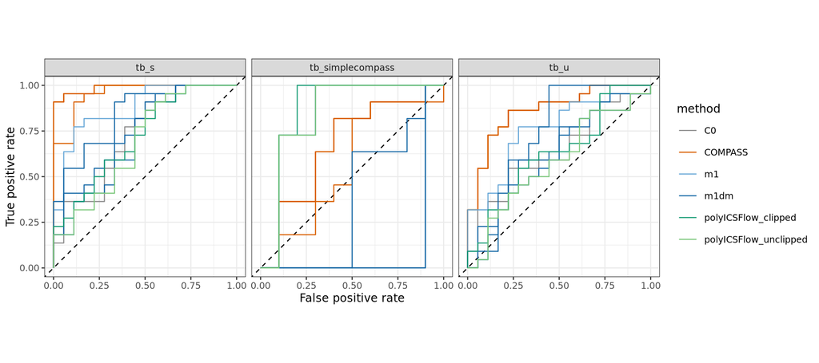

```r
roc_of <- \(wide, column) {
  s <- wide[[column]]
  y <- wide$case
  th <- sort(unique(s), decreasing = TRUE)
  tibble(
    column = column,
    fpr = c(0, map_dbl(th, \(t) mean(s[!y] >= t))),
    tpr = c(0, map_dbl(th, \(t) mean(s[y] >= t)))
  )
}
wide <- by_ds("donor_wide.tsv")
roc <- wide |>
  split(wide$dataset) |>
  map(\(w) map(HEADLINE, \(h) roc_of(w, h)) |> list_rbind()) |>
  list_rbind(names_to = "dataset") |>
  mutate(method = word(column, 1))
ggplot(roc, aes(fpr, tpr, colour = method, group = column)) +
  geom_abline(linetype = 2) +
  geom_step(linewidth = 0.4) +
  scale_colour_manual(values = method_pal) +
  facet_wrap(vars(dataset), nrow = 1) +
  coord_equal() +
  labs(x = "False positive rate", y = "True positive rate")
```

## Rank agreement

The Spearman correlation across donors measures whether the methods order donors alike; each point below is one donor.

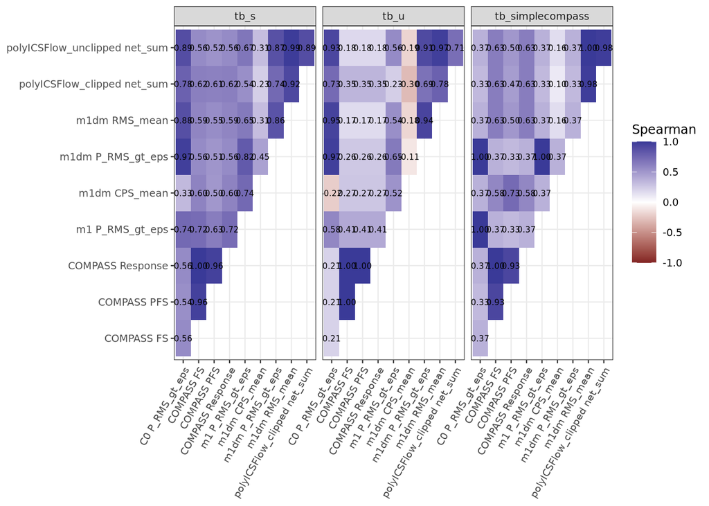

```r
agr <- by_ds("agreement.tsv") |> mutate(spearman = round(spearman, 2))
ggplot(agr, aes(a, b, fill = spearman, label = sprintf("%.2f", spearman))) +
  geom_tile() +
  geom_text(size = 2) +
  scale_fill_gradient2(limits = c(-1, 1), midpoint = 0) +
  facet_wrap(vars(dataset), nrow = 1) +
  theme(axis.text.x = element_text(angle = 60, hjust = 1)) +
  labs(x = NULL, y = NULL, fill = "Spearman")
```

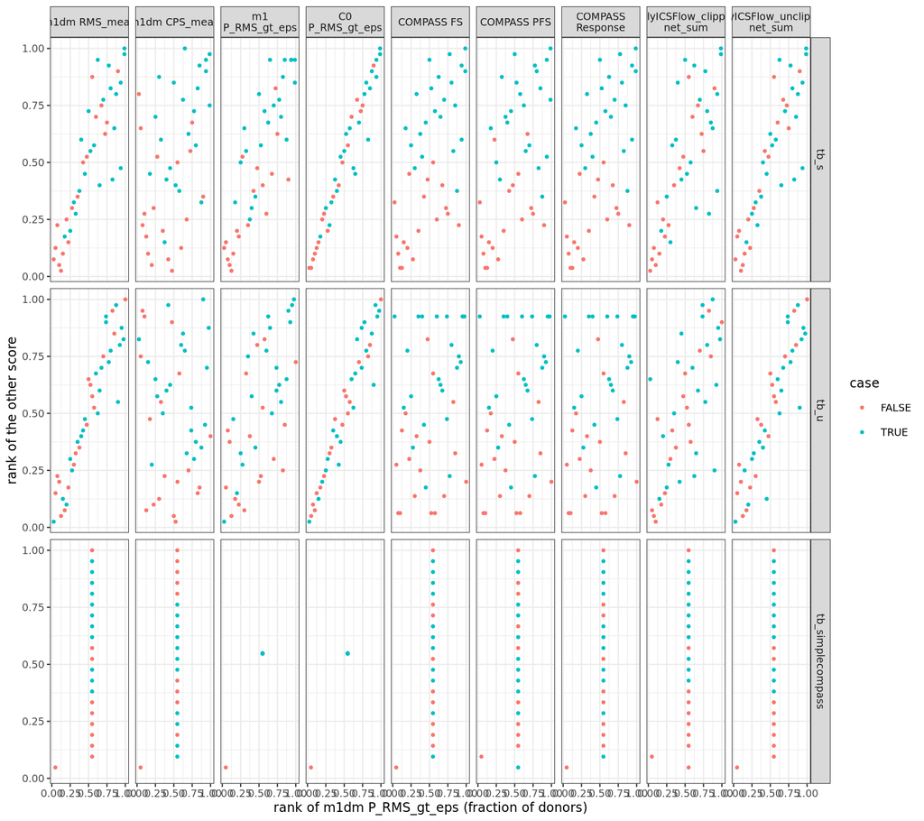

```r
others <- setdiff(HEADLINE, HEADLINE[1])
scatter <- wide |>
  select(dataset, donor_id, case, all_of(HEADLINE)) |>
  mutate(across(all_of(HEADLINE), \(v) rank(v) / length(v)), .by = dataset) |>
  pivot_longer(all_of(others), names_to = "other", values_to = "rank_other") |>
  mutate(other = fct(other, levels = others))
ggplot(scatter, aes(.data[[HEADLINE[1]]], rank_other, colour = case)) +
  geom_point(size = 0.8) +
  facet_grid(dataset ~ other, labeller = labeller(other = label_wrap_gen(14))) +
  labs(x = paste("rank of", HEADLINE[1], "(fraction of donors)"), y = "rank of the other score", colour = "case")
```

## Specific against non-specific antigens

TB_s and TB_u share donors and the unstimulated count, so each donor is one paired point of response magnitude; this is a sanity check, not a comparison of methods.

```r
su <- wide |>
  filter(dataset %in% c("tb_s", "tb_u")) |>
  select(dataset, donor_id, case, `m1dm RMS_mean`, `polyICSFlow_clipped net_sum`, `COMPASS FS`) |>
  pivot_longer(c(`m1dm RMS_mean`, `polyICSFlow_clipped net_sum`, `COMPASS FS`), names_to = "score") |>
  pivot_wider(names_from = dataset, values_from = value)
su |>
  summarise(
    median_s = median(tb_s), median_u = median(tb_u),
    p_wilcoxon_paired = wilcox.test(tb_s, tb_u, paired = TRUE, exact = FALSE)$p.value,
    spearman = cor(tb_s, tb_u, method = "spearman"),
    .by = score
  ) |>
  knitr::kable(digits = 4)
```

| score | median_s | median_u | p_wilcoxon_paired | spearman |
| --- | --- | --- | --- | --- |
| m1dm RMS_mean | 0.0006 | 3e-04 | 0.0572 | 0.6572 |
| polyICSFlow_clipped net_sum | 0.0011 | 9e-04 | 0.0280 | 0.7824 |
| COMPASS FS | 0.0299 | 3e-02 | 0.0252 | 0.6215 |

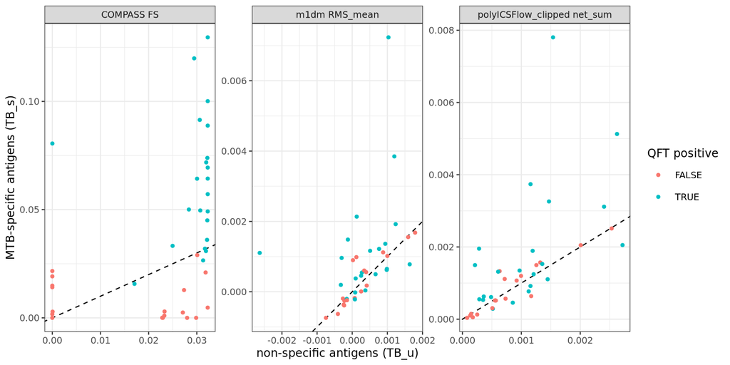

```r
ggplot(su, aes(tb_u, tb_s, colour = case)) +
  geom_abline(linetype = 2) +
  geom_point(size = 1) +
  facet_wrap(vars(score), scales = "free") +
  labs(x = "non-specific antigens (TB_u)", y = "MTB-specific antigens (TB_s)", colour = "QFT positive")
```

## Overdispersion of m1dm

phi is the Dirichlet-multinomial precision; a posterior far from zero in 1/phi means the counts are more variable than a multinomial allows.

```r
by_ds("phi_summary.tsv") |> mutate(across(where(is.numeric), \(v) signif(v, 3))) |> knitr::kable()
```

| dataset | variable | mean | sd | q5 | q95 | rhat | ess_bulk |
| --- | --- | --- | --- | --- | --- | --- | --- |
| tb_s | inv_phi[1] | 2.30e-04 | 1.73e-05 | 2.04e-04 | 2.60e-04 | 1 | 5920 |
| tb_s | phi[1] | 4.37e+03 | 3.26e+02 | 3.84e+03 | 4.91e+03 | 1 | 5920 |
| tb_u | inv_phi[1] | 2.14e-04 | 1.75e-05 | 1.87e-04 | 2.45e-04 | 1 | 3020 |
| tb_u | phi[1] | 4.71e+03 | 3.84e+02 | 4.08e+03 | 5.36e+03 | 1 | 3020 |
| tb_simplecompass | inv_phi[1] | 8.62e-03 | 8.33e-04 | 7.35e-03 | 1.01e-02 | 1 | 2220 |
| tb_simplecompass | phi[1] | 1.17e+02 | 1.12e+01 | 9.94e+01 | 1.36e+02 | 1 | 2220 |

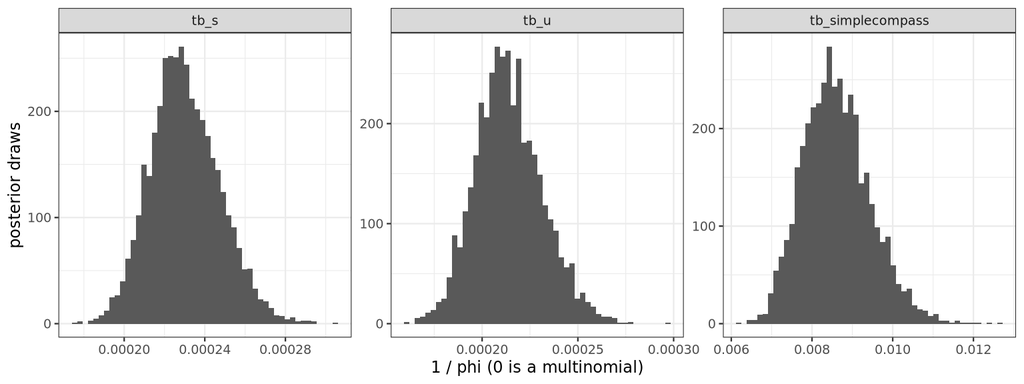

```r
phi <- by_ds("phi_draws.tsv")
ggplot(phi, aes(inv_phi)) +
  geom_histogram(bins = 50) +
  facet_wrap(vars(dataset), nrow = 1, scales = "free") +
  labs(x = "1 / phi (0 is a multinomial)", y = "posterior draws")
```

## LOO, m1dm against m1

Leave-one-sample-out elpd; the observation is one sample, so a Pareto-k above 0.7 marks a sample whose removal moves the donor effects and makes that estimate unreliable.

```r
by_ds("loo.tsv") |> mutate(across(where(is.numeric), \(v) round(v, 1))) |> knitr::kable()
```

| dataset | model | elpd_loo | se_elpd_loo | p_loo | n_samples | n_k_gt_0.7 | n_k_gt_1 | max_k |
| --- | --- | --- | --- | --- | --- | --- | --- | --- |
| tb_s | m1dm | -3281.5 | 116.8 | 84.6 | 80 | 40 | 6 | 1.3 |
| tb_s | m1 | -5480.2 | 430.1 | 242.3 | 80 | 72 | 15 | 2.4 |
| tb_u | m1dm | -3011.1 | 93.3 | 52.9 | 80 | 14 | 0 | 1.0 |
| tb_u | m1 | -5182.5 | 333.6 | 221.0 | 80 | 56 | 14 | 1.4 |
| tb_simplecompass | m1dm | -4556.7 | 219.7 | 68.2 | 42 | 13 | 1 | 2.3 |
| tb_simplecompass | m1 | -60222.4 | 13717.3 | 2956.0 | 42 | 42 | 40 | 26.4 |

```r
by_ds("loo_compare.tsv") |> mutate(across(where(is.numeric), \(v) round(v, 1))) |> knitr::kable()
```

| dataset | model | elpd_diff | se_diff |
| --- | --- | --- | --- |
| tb_s | m1dm | 0.0 | 0.0 |
| tb_s | m1 | -2198.7 | 342.7 |
| tb_u | m1dm | 0.0 | 0.0 |
| tb_u | m1 | -2171.4 | 262.4 |
| tb_simplecompass | m1dm | 0.0 | 0.0 |
| tb_simplecompass | m1 | -55665.7 | 13545.1 |

## Posterior predictive checks

Replicates come from the structured mean (not from the sample probability, which is conditioned on the observed counts); a model that fits has the observed value inside the 90% interval for about 90% of samples.

```r
ppc_s <- by_ds("ppc_sample.tsv")
ppc_s |>
  summarise(
    n = n(), coverage_90 = mean(observed >= lower & observed <= upper),
    frac_p_extreme = mean(p_mid < 0.025 | p_mid > 0.975),
    .by = c(dataset, model, statistic)
  ) |>
  knitr::kable(digits = 2)
```

| dataset | model | statistic | n | coverage_90 | frac_p_extreme |
| --- | --- | --- | --- | --- | --- |
| tb_s | m1dm | any_positive | 80 | 0.84 | 0.10 |
| tb_s | m1dm | n_rare_patterns | 80 | 0.94 | 0.06 |
| tb_s | m1 | any_positive | 80 | 0.76 | 0.19 |
| tb_s | m1 | n_rare_patterns | 80 | 0.88 | 0.11 |
| tb_u | m1dm | any_positive | 80 | 0.86 | 0.09 |
| tb_u | m1dm | n_rare_patterns | 80 | 0.92 | 0.07 |
| tb_u | m1 | any_positive | 80 | 0.72 | 0.20 |
| tb_u | m1 | n_rare_patterns | 80 | 0.84 | 0.16 |
| tb_simplecompass | m1dm | any_positive | 42 | 0.12 | 0.79 |
| tb_simplecompass | m1dm | n_rare_patterns | 42 | 0.81 | 0.12 |
| tb_simplecompass | m1 | any_positive | 42 | 0.57 | 0.38 |
| tb_simplecompass | m1 | n_rare_patterns | 42 | 0.29 | 0.71 |

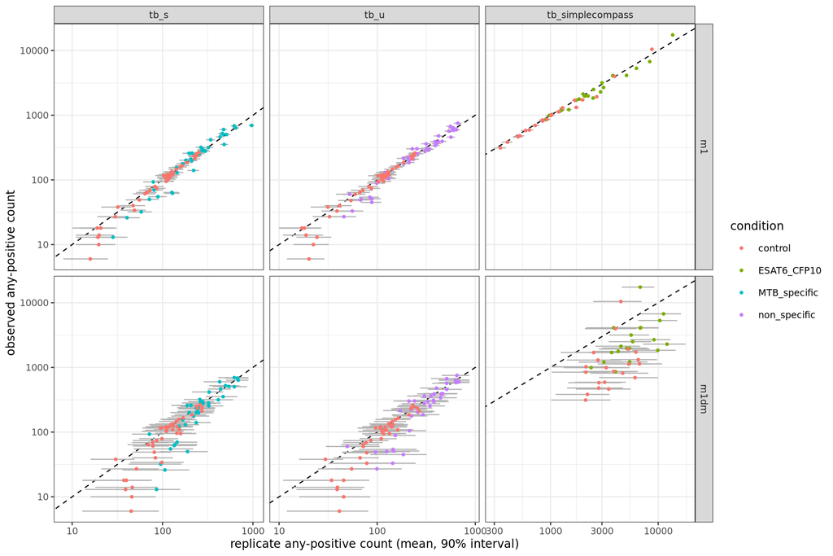

```r
ggplot(ppc_s |> filter(statistic == "any_positive"), aes(rep_mean, observed)) +
  geom_abline(linetype = 2) +
  geom_linerange(aes(xmin = lower, xmax = upper), colour = "grey70") +
  geom_point(aes(colour = condition), size = 0.8) +
  scale_x_log10() +
  scale_y_log10() +
  facet_grid(model ~ dataset, scales = "free") +
  labs(x = "replicate any-positive count (mean, 90% interval)", y = "observed any-positive count")
```

```r
ppc_p <- by_ds("ppc_pattern.tsv")
ppc_p |>
  summarise(
    n = n(), coverage_90 = mean(observed >= lower & observed <= upper),
    frac_p_extreme = mean(p_mid < 0.025 | p_mid > 0.975),
    .by = c(dataset, model, statistic)
  ) |>
  knitr::kable(digits = 2)
```

| dataset | model | statistic | n | coverage_90 | frac_p_extreme |
| --- | --- | --- | --- | --- | --- |
| tb_s | m1dm | total | 64 | 0.80 | 0.16 |
| tb_s | m1dm | n_zero_samples | 64 | 0.75 | 0.23 |
| tb_s | m1 | total | 64 | 0.69 | 0.28 |
| tb_s | m1 | n_zero_samples | 64 | 0.75 | 0.25 |
| tb_u | m1dm | total | 64 | 0.75 | 0.20 |
| tb_u | m1dm | n_zero_samples | 64 | 0.78 | 0.22 |
| tb_u | m1 | total | 64 | 0.67 | 0.28 |
| tb_u | m1 | n_zero_samples | 64 | 0.72 | 0.28 |
| tb_simplecompass | m1dm | total | 64 | 0.66 | 0.30 |
| tb_simplecompass | m1dm | n_zero_samples | 64 | 0.44 | 0.53 |
| tb_simplecompass | m1 | total | 64 | 0.34 | 0.64 |
| tb_simplecompass | m1 | n_zero_samples | 64 | 0.42 | 0.56 |

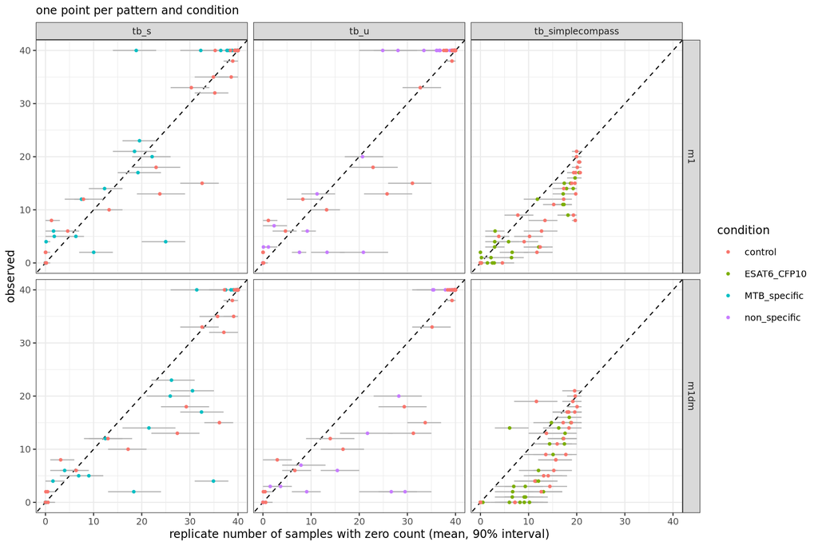

```r
ggplot(ppc_p |> filter(statistic == "n_zero_samples"), aes(rep_mean, observed)) +
  geom_abline(linetype = 2) +
  geom_linerange(aes(xmin = lower, xmax = upper), colour = "grey70") +
  geom_point(aes(colour = condition), size = 0.8) +
  facet_grid(model ~ dataset) +
  labs(x = "replicate number of samples with zero count (mean, 90% interval)", y = "observed", subtitle = "one point per pattern and condition")
```

## Runtime

Seconds per method on the same counts; cytoJointR Stan fits use 4 CPUs, the other methods 1.

```r
rt <- bind_rows(
  by_ds("runtime.tsv"),
  names(DATASETS) |> set_names() |> map(\(ds) rd(ds, "polyicsflow/runtime.tsv")) |> list_rbind(names_to = "dataset")
) |>
  mutate(dataset = fct(as.character(dataset), levels = names(DATASETS)))
rt |>
  pivot_wider(names_from = dataset, values_from = seconds, id_cols = c(method, step, cpus)) |>
  knitr::kable(digits = 1)
```

| method | step | cpus | tb_s | tb_u | tb_simplecompass |
| --- | --- | --- | --- | --- | --- |
| m1dm | fit | 4 | 81.0 | 72.4 | 56.5 |
| m1 | fit | 4 | 90.1 | 77.2 | 327.2 |
| C0 | fit | 1 | 3.7 | 3.5 | 2.0 |
| m1dm | cj_scores | 1 | 5.1 | 4.6 | 3.0 |
| m1 | cj_scores | 1 | 3.7 | 3.4 | 2.1 |
| C0 | cj_scores | 1 | 5.7 | 5.3 | 3.3 |
| COMPASS | cj_compass | 1 | 70.4 | 54.6 | 118.2 |
| polyICSFlow | expand_counts_to_cells | 1 | 7.4 | 8.9 | 7.1 |
| polyICSFlow | assignMarkerCombinations | 1 | 35.1 | 44.2 | 24.0 |
| polyICSFlow | calcPolyfunctionality | 1 | 0.4 | 0.5 | 0.3 |